# Tutorial 7: Comparing Two Means

Analysing Data

This tutorial covers how to prepare for, complete, and report *t*-tests in R. Before you begin this tutorial, make sure you review the [Week 6 lecture](https://canvas.sussex.ac.uk/courses/9242/pages/week-6?module_item_id=612284) covering comparing two means. This tutorial will do this two ways: first as a *t*-test, which is what you should do for your lab report; and second as a linear model. This will help demonstrate how these two analyses are actually capturing the same relationship.

## Which Analysis?

If you are planning to write about [the red study (Elliot et al., 2010)](https://canvas.sussex.ac.uk/courses/9242/pages/Lab%20Report%20Information%20and%20Resources#red) for your lab report, this is the tutorial that will teach you the analysis to use. If you are planning to write about [the green study (Griskevicius et al, 2010)](https://canvas.sussex.ac.uk/courses/9242/pages/Lab%20Report%20Information%20and%20Resources#green), then you should review [last week’s tutorial and practical on chi-squared](https://canvas.sussex.ac.uk/courses/9242/pages/week-6) instead.

## Setting Up

Just like last time, all you need for this tutorial is this file and RStudio. Remember that you can easily switch between windows with the `Alt` + `↹ Tab` (Windows) and `⌘ Command` + `⇥ Tab` (Mac OS) shortcuts.

### Task 1

Open your analysing_data `R` project in RStudio and open a new Markdown file. Since we will be practicing reporting using inline code, we will need Markdown later on. For the tasks, get into the habit of creating new code chunks as you go.

### Task 2

Aside from loading `tidyverse`, we will also be using `Hmisc`, `here`, `cowplot`, and `kableExtra`. If you don’t have any of these packages installed, do that now. **Remember that installing packages is a one-off thing** so don’t put the command that does it in your Markdown. Simply type it into the console and press `↵ Enter`. The `library()` commands should always go in a separate code chunk at the beginning of your Markdown document, so that your code will run correctly.

**Solution**

```r
install.packages("Hmisc")
library(tidyverse)
library(Hmisc)
library(here)
library(kableExtra)
library(cowplot)
```

As usual, we will need some data to work with. Let’s have another look at last week’s practical data, `sync`.

### Task 3

Read in the `sync` data ([which you can use this link to download](http://users.sussex.ac.uk/~jm636/synchrony_short.csv)) and copy over the code you wrote for [last week’s practical](http://users.sussex.ac.uk/~jm636/prac_05_wkst_sol.html) to clean it. If you haven’t finished this yet, you may want to do this first, or work through the posted solutions, before you continue with this tutorial.

**Solution**

```r
sync <- read_csv("http://users.sussex.ac.uk/~jm636/synchrony_short.csv")

# Data checking
## Remove problematic value and recode age
sync <- sync %>%
  mutate(Age = recode(Age, "3p" = "300"),
         Age = as.numeric(Age))

## Recode factor variables as factors with labels
sync <- sync %>%
  mutate(Px = factor(Px),
         Gender = factor(Gender, labels = c("Male", "Female")),
         condition = factor(condition, labels = c("Synchrony", "Asynchrony")))

# Data cleaning
## Remove improbable values of age
## Don't forget to save the number you will remove before you do it!

age_removed <- sync %>% filter(Age > 99) %>% nrow()

sync <- sync %>%
  filter(Age < 100)

# Replace impossible score with NA
# Using na_if()
sync <- sync %>%
  mutate(nars3 = na_if(nars3, 25))

## Remove participants with all NAs
# and save how many we'll remove before we do so.
na_removed <- sync %>% filter(rowSums(is.na(sync)) > 5) %>% nrow()

sync <- sync %>%
  filter(rowSums(is.na(sync)) < 6)
```

## Data Preparation

As usual, before beginning any analysis, we will want to take a look at our data to make sure it’s clean and correct before we proceed. Since we’re using our familiar `sync` dataset that we’ve cleaned already, we should be pretty happy with this, but let’s have a look again at these variables. If you don’t remember what your variables measure, then the numbers you get from your analysis won’t mean anything!

### Task 4

Review the codebook below and compare to your data using any method you like. If there are any differences or problems, fix them before you proceed.

### Codebook

| Variable | Type | Description |
| --- | --- | --- |
| Px | Factor | Participant number |
| Age | Numeric | Participant age in years |
| Gender | Factor | Participant gender; 0 = Male, 1 = Female |
| condition | Factor | Synchrony experimental condition; 0 = Synchrony, 1 = Asynchrony |
| liking | Numeric | Rating of how much the participants liked Pepper, from 0 (not at all) to 5 (very much) |
| anth | Numeric | Rating of how anthropomorphic participants found Pepper, from 0 (not at all) to 5 (very much) |
| perc.int | Number | Rating of how intelligent participants perceived Pepper to be, from 0 (not intelligent at all) to 5 (very intelligent) |
| nars1 | Number | Negative Attitude toward Robots subscale 1 (interaction with robots), higher score = more negative; total of six questions on a scale of 1 - 5, max score 30 |
| nars2 | Number | Negative Attitude toward Robots subscale 2 (social influence of robots), higher score = more negative; total of five questions on a scale of 1 - 5, max score 25 |
| nars3 | Number | Negative Attitude toward Robots subscale 3 (emotions in interactions with robots), higher score = more negative; total of three questions on a scale of 1 - 5, max score 15 |

**Solution**

```r
# Use one or (better!) all of the following
# to have a look at your data
# Run just one at a time by putting your cursor
# anywhere inside the command and pressing ctrl + Enter
# or cmd + Enter on Macs

# Open the dataset in the Viewer, or just click on the object in Environment
View(sync)

# Create a summary of each variable
sync %>% summary()

# Look at the structure of the dataset
sync %>% str()

# Print out a preview of the tibble in the console
sync
```

Thus far, everything looks good. We can see from the codebook that we have three ratings of people’s opinions of Pepper (`liking`, `anth`, and `perc.int`) and three measures on the NARS (`nars1`, `nars2`, `nars3`). We can take a look at these measures individually, but it would also be useful to create a **composite score** out of these individual ratings.

## Creating a Composite Score

Composite scores can be created in different ways, but we’re just going to use perhaps the easiest: the mean. What we would like to do is calculate a new variable that is the mean of each person’s scores on the three opinion scales (i.e. `liking`, `anth`, and `perc.int`). These three questions are all different aspects of people’s opinions about Pepper and they’re all on the same scale (i.e. 0 - 5), so we can take the mean of the three ratings that each person gave and create a new variable, `opinion_comp`, on the same scale that captures all three ratings together.

### Attempt 1: `c()`

To do this, we might first try the following, using the following familiar code. Here, we put `liking`, `anth`, and `perc.int` into `c()` because we want all three of them to go in the first argument of `mean()` together. See the box further down about using `c()` if you’re not sure how this works.

```r
sync %>%
  mutate(opinion_comp = mean(c(liking, anth, perc.int))) %>%
# You don't need the line below,
# it's only to make it easier to quickly find the new variable
  select(Px, liking, anth, perc.int, opinion_comp)
# A tibble: 60 x 5
   Px    liking  anth perc.int opinion_comp
   <fct>  <dbl> <dbl>    <dbl>        <dbl>
 1 6        4.8   3.6      4.8           NA
 2 10       4     1.8      2.2           NA
 3 13       4.8   1.2      3             NA
 4 47       3.6   1.6      3.2           NA
 5 68       4     1.8      4.2           NA
 6 1        5     1.8      3             NA
 7 2        3.8   3.8      4.2           NA
 8 5        3.6   3.2      4             NA
 9 7        5     4.4      4.6           NA
10 9        3.8   2.4      4.6           NA
# ... with 50 more rows
```

This works…or at least, it runs (not the same thing!). If we look at the new variable at the end of our `sync` tibble, we can see that `opinion_comp` has been created, but there’s nothing in it but NAs! What happened?

Thinking back to our summary, we might remember that there were some NAs in our data. As long as there is at least one NA in at least one of the variables, `mean()` will return NA. However, we might not have known this unless we checked! R didn’t give us an error because as far as R was concerned, it did what we asked it to do without any problems.

### Attempt 2: `na.rm`

Let’s try again, this time telling R to ignore any NAs using `na.rm = T`:

```r
sync %>%
  mutate(opinion_comp = mean(c(liking, anth, perc.int), na.rm = T)) %>%
  select(Px, liking, anth, perc.int, opinion_comp)
# A tibble: 60 x 5
   Px    liking  anth perc.int opinion_comp
   <fct>  <dbl> <dbl>    <dbl>        <dbl>
 1 6        4.8   3.6      4.8         3.51
 2 10       4     1.8      2.2         3.51
 3 13       4.8   1.2      3           3.51
 4 47       3.6   1.6      3.2         3.51
 5 68       4     1.8      4.2         3.51
 6 1        5     1.8      3           3.51
 7 2        3.8   3.8      4.2         3.51
 8 5        3.6   3.2      4           3.51
 9 7        5     4.4      4.6         3.51
10 9        3.8   2.4      4.6         3.51
# ... with 50 more rows
```

At first glance, this seems fine - we have numbers in `opinion_comp` now. But on closer look, we can see that they’re all the same number, even though we can see from the tibble printout that each row has different values in it. What happened?

This time, R has again quietly done what we’ve asked. We asked it to calculate the mean of our three variables, and store that value in `opinion_comp`. What R didn’t do (because we didn’t tell it to!) is calculate a new mean **for each case**. Instead, R calculated the **overall mean** of all of the numbers in all three variables and stored that one value for every case. This is not what we wanted, but again, R doesn’t know that; it’s just done what we asked it to do.

### Attempt 3: `group_by()`

Right, what we really want is that `opinion_comp` will contain the mean of the three ratings calculated for each person individually. We’ve solved a similar problem before using `group_by()`. Let’s try grouping by `Px`, our participant code, which we’ve used previously in descriptive tables for a similar purpose.

```r
sync %>%
  group_by(Px) %>%
  mutate(opinion_comp = mean(c(liking, anth, perc.int), na.rm = T)) %>%
  select(Px, liking, anth, perc.int, opinion_comp)
# A tibble: 60 x 5
# Groups:   Px [60]
   Px    liking  anth perc.int opinion_comp
   <fct>  <dbl> <dbl>    <dbl>        <dbl>
 1 6        4.8   3.6      4.8         4.4
 2 10       4     1.8      2.2         2.67
 3 13       4.8   1.2      3           3
 4 47       3.6   1.6      3.2         2.8
 5 68       4     1.8      4.2         3.33
 6 1        5     1.8      3           3.27
 7 2        3.8   3.8      4.2         3.93
 8 5        3.6   3.2      4           3.6
 9 7        5     4.4      4.6         4.67
10 9        3.8   2.4      4.6         3.6
# ... with 50 more rows
```

Aha, third time lucky! Now we can see that there are different numbers for each person in `opinion_comp`. If we’re feeling a bit paranoid now that R’s done something we weren’t expecting a few times, we can check that this calculation is what we think it should be by choosing a random person and calculating the mean for ourselves, using R as a calculator. Looking at our tibble above, we can see our participant with ID code 7 (i.e., `Px` = 7) gave `liking`, `anth`, and `perc.int` ratings of 5, 4.4, and 4.6 respectively. Let’s do the mean calculation ourselves:

```r
(5 + 4.4 + 4.6) / 3
[1] 4.666667
```

The result is the same number that is stored for participant 7 in `opinion_comp`.

### Success!

Now that we have code that works, we can actually create this variable in our dataset by using `<-` to assign it back into the same object. This will overwrite our original `sync` dataset with our new one, which is identical except for the new variable `opinion_comp`.

### Task 5

Make the change to your dataset `sync`. When you do, you must include one more important element. After we create `opinion_comp`, we must remember to **ungroup** our dataset again. If we don’t, we may get weird results down the line, because R will try to make plots or do analyses for every participant individually! We can do this easily with `ungroup()`.

**Solution**

```r
sync <- sync %>%
  group_by(Px) %>%
  mutate(opinion_comp = mean(c(liking, anth, perc.int), na.rm = T)) %>%
  ungroup()
```

### Task 6

Create two new variables in the `sync` data:

- `nars_total`, which is the sum of the scores on the three NARS scales
  - Hint: try `?sum`
- `nars_comp`, which is the mean rating across all three NARS scales
  - Refer to the codebook to figure out how many questions you need to divide by!

**Solution**

```r
sync <- sync %>%
  group_by(Px) %>%
  mutate(nars_total = sum(nars1, nars2, nars3),
         nars_comp = nars_total/14) %>%
  ungroup()

# Call the dataset to see the new variables
sync
# A tibble: 60 x 13
   Px      Age Gender condition liking  anth perc.int nars1 nars2 nars3 opinion_comp
   <fct> <dbl> <fct>  <fct>      <dbl> <dbl>    <dbl> <dbl> <dbl> <dbl>        <dbl>
 1 6        22 Female Synchrony    4.8   3.6      4.8    10    13     6         4.4
 2 10       17 Male   Asynchro~    4     1.8      2.2     8    12    10         2.67
 3 13       23 Male   Asynchro~    4.8   1.2      3      10    16    11         3
 4 47       18 Female Asynchro~    3.6   1.6      3.2    16    15    10         2.8
 5 68       19 Female Synchrony    4     1.8      4.2    15    21    10         3.33
 6 1        21 Female Asynchro~    5     1.8      3      14    21     7         3.27
 7 2        21 Female Synchrony    3.8   3.8      4.2    13    14     7         3.93
 8 5        21 Female Synchrony    3.6   3.2      4      17    16     9         3.6
 9 7        21 Female Asynchro~    5     4.4      4.6    11    14     6         4.67
10 9        21 Female Synchrony    3.8   2.4      4.6    16    19     9         3.6
# ... with 50 more rows, and 2 more variables: nars_total <dbl>, nars_comp <dbl>
```

**Further Explanation**

Each argument within `mutate` creates the two new variables for this task. The first uses `sum()` to add together the scores on the three NARS scales. We can see by asking for a summary that `nars_total` now contains scores ranging from 20 to 56:

```r
sync %>%
  pull(nars_total) %>%
  summary()
   Min. 1st Qu.  Median    Mean 3rd Qu.    Max.    NA's
  20.00   34.00   41.00   40.41   45.75   56.00       2
```

Referring again to the codebook, we can see that the three NARS scales were measured on a scale of 1 - 5, and each contain different numbers of questions: 6, 5, and 3 respectively. So, to find the mean rating on these three scales, we first need to add 6, 5, and 3 to find the total number of questions on the NARS. You can do this in your head or use R:

```r
6 + 5 + 3
[1] 14
```

This means that to find the mean NARS score, we have to divide by 14, because there were 14 questions total and we want the mean score per question. So, we can’t use `mean()`, because that will divide by the number of variables we put into it (i.e. three: `nars1`, `nars2`, and `nars3`). Instead we can use the total score across the three scales we calculated in the first step, `nars_total`, and divide by the number of questions on the NARS altogether, which is 14, to get the mean per question.

**Note:** The creator of the NARS scales do not recommend averaging across the scales like this! So we’ll do it for practice, but you should always research your scales carefully before you start transforming them like this.

#### Using `c()`

We have come across the humble `c()` many times already, both this semester and last semester. `c()` stands for “concatenate”, or “collect”, or “combine”, or something to that effect. The idea is that you can put any number of things into `c()`, and they will be combined into a single vector (basically a series).

This is a useful thing to be able to do because of the way arguments work in R. Let’s have a look at the task we just did using `mean()`. Before we start, type `?mean` or `help(mean)` into your console and press Enter to see the documentation for this function.

From the documentation we can see that `mean()`’s first argument, `x`, has to contain everything you want to take the mean of. It also has more arguments, `trim` and `na.rm` and so on, some of which we have used before. In the composite score example above, though, we had three variables that we wanted to take the mean of. Let’s have a look at what would happen without `c()` by running the following code:

```r
sync %>%
  group_by(Px) %>%
  mutate(opinion_comp = mean(liking, anth, perc.int))
```

[output not shown]

```r
mean(liking, anth, perc.int)
```

```r
mean(x = liking, trim = anth, na.rm = perc.int)
```

Understandably, R has complained about this; `trim = anth` is nonsense and not at all what we wanted, much less `na.rm = perc.int`! Instead, we need to tell R that we want all three variables, together, to go in the `x` argument. This is where `c()` comes in. It allows us to put multiple things into one argument together, so instead we can write:

```r
mean(c(liking, anth, perc.int))
```

and R will understand that we want the mean of all three of those variables, because they are all together in the `x` argument.

Overall `c()` is terribly useful and pops up all over the place. You should use it whenever you need to give R more than one thing at a time, which is often the case. Now when you see it in our examples, try to work out what it’s doing and why - and remember to use it yourself!

## Graphing

Before we jump into calculating numbers, we should get an idea of what our data look like. This will help us better understand the numbers we get from our analysis.

### Histograms

The first thing we should do is have a look at some histograms to get a sense of how people responded to these questions. Let’s start by looking at histograms of all of our rating variables. If you don’t remember `pivot_longer`, have a look at last week’s tutorial for a reminder.

### Task 7

Copy the code below and replace the ellipses `...` with the correct elements. For `select()`, only keep the three opinion ratings and their composite mean, and the composite mean of the NARS scales.

```r
 sync %>%
  select(...)
  pivot_longer(everything(), names_to = "variable", values_to = "value") %>%
  ggplot(...(value)) +
  ...() +
  ...(~variable) +
  theme_...()
```

**Solution**

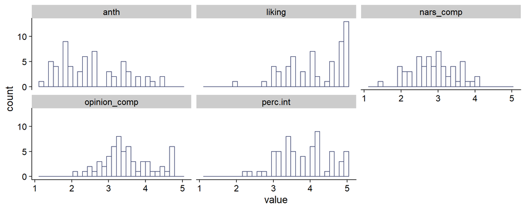

```r
sync %>%
  select(liking, anth, perc.int, opinion_comp, nars_comp) %>%
  pivot_longer(everything(), names_to = "variable", values_to = "value") %>%
  ggplot(aes(value)) +
  geom_histogram() +
  facet_wrap(~variable) +
# You don't have to use cowplot - try different themes if you like!
  theme_cowplot()
```

Here we can get a sense of how our data is distributed in each variable. It looks like people tended to like Pepper the robot a lot, since the scores tend to be piled up on the high end of the scale in `liking`; but they didn’t think she was very human-like, which gives us the reverse pattern in `anth`. They did think she was reasonably intelligent (`perc.int`), but the scores here are a bit more symmetrical than in `liking`. The distribution of our composite scores, `opinion_comp` and `nars_comp`, are a bit more centred in the scale and symmetrical.